# Stroop test

## 1. What is our independent variable? What is our dependent variable?

The dependent variable is the *performance of the respondent*, which can be measured by the reaction time of the respondent.

The independent variable is the *experimental condition*, namely a congruent condition (color and word are congruent) or a incongruent condition (color and word are incongruent).

## 2. What is an appropriate set of hypotheses for this task? What kind of statistical test do you expect to perform? Justify your choices.

I suggest to use a one-sided t-test because we want to know if respondents in the incongruent condition need more time to answer the questions. In this case, the hypotheses are the following:

$$\ H_0: (μIncon-μCon) ≤ 0$$

$$\ H_1: (μIncon-μCon) > 0$$

$\ H_0$ claims that the difference between the two groups is (smaller) than 0. $\ H_1$ claims the opposite, namely that the difference between both means is significantly different from 0.

$\ μIncon$ indicates the mean of the population in the incongruent condition, while $\ μCon$ indicates the mean for the congruent condition.

The z-test should be used when the standard deviation in the population is known and the number of observations is greater than 30. In this case, there are only 24 observations and we do not know the standard deviation of the population because we draw a sample. Therefore, a t-test is the better option.

I conduct a *paired* t-test, because in the experiment each subject is measured twice.

An two-sided test would also be possible, but there is a clear indication of the expected direction in this test.

## 3. Report some descriptive statistics regarding this dataset. Include at least one measure of central tendency and at least one measure of variability.

One measure of *central tendency* is the mean:

```r
summary(df$Congruent)
```

```
##    Min. 1st Qu.  Median    Mean 3rd Qu.    Max.
##    8.63   11.90   14.36   14.05   16.20   22.33
```

```r
summary(df$Incongruent)
```

```
##    Min. 1st Qu.  Median    Mean 3rd Qu.    Max.
##   15.69   18.72   21.02   22.02   24.05   35.26
```

The mean reaction time for the incongruent condition is 22.02 seconds, larger than the reaction time in the congruent condition of 14.05 seconds. However, we have to assess if this difference is statistically significant on a predefined significance level.

One measures of *variabilit* is the *standard deviation*:

```r
congruent_sd <- sd(df$Congruent)
incongruent_sd <- sd(df$Incongruent)

congruent_sd
```

```
## [1] 3.559358
```

```r
incongruent_sd
```

```
## [1] 4.797057
```

The variance in the incongruent is larger than in the congruent condition.

## 4. Provide one or two visualizations that show the distribution of the sample data. Write one or two sentences noting what you observe about the plot or plots.

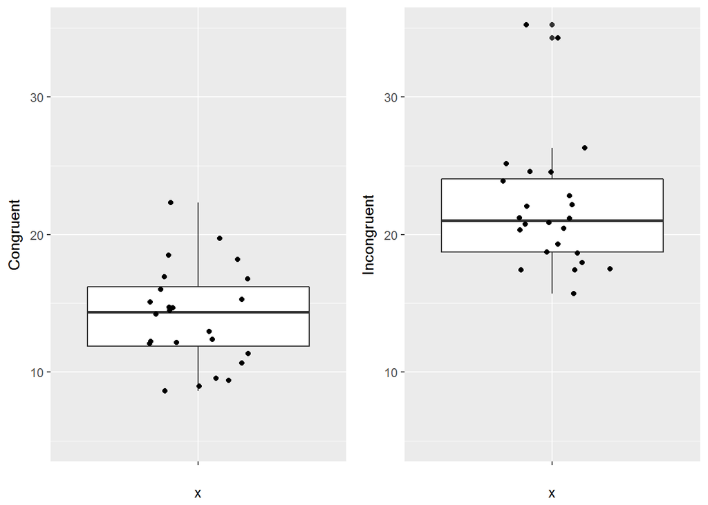

```r
library(ggplot2)
library(gridExtra)

# Create boxplots for both variables
p1 <- ggplot(df, aes(y = Congruent, x = "")) +
  geom_boxplot() +
  coord_cartesian(ylim = c(5, 35)) +
  geom_jitter(width = 0.2)

p2 <- ggplot(df, aes(y = Incongruent, x = "")) +
  geom_boxplot() +
  coord_cartesian(ylim = c(5, 35)) +
  geom_jitter(width = 0.2)

grid.arrange(p1, p2, ncol = 2)
```

## 5. Now, perform the statistical test and report your results. What is your confidence level and your critical statistic value? Do you reject the null hypothesis or fail to reject it? Come to a conclusion in terms of the experiment task. Did the results match up with your expectations?

```r
n=nrow(df)
# Critical value for df=23, one sided
abs(qt(0.05, n-1))
```

```
## [1] 1.713872
```

```r
# means
congruent_mean <- mean(df$Congruent)
incongruent_mean <- mean(df$Incongruent)

# One tailed 95% CI of congruent and incongruent
congruent_mean + qt(0.95,df=n-1)*congruent_sd/sqrt(n)
```

```
## [1] 15.29634
```

```r
incongruent_mean - qt(0.95,df=n-1)*incongruent_sd/sqrt(n)
```

```
## [1] 20.3377
```

```r
# Perform two-sided  t-test
t.test(df$Incongruent, df$Congruent,paired=TRUE, alternative = 'greater')
```

```
##
##  Paired t-test
##
## data:  df$Incongruent and df$Congruent
## t = 8.0207, df = 23, p-value = 2.052e-08
## alternative hypothesis: true difference in means is greater than 0
## 95 percent confidence interval:
##  6.262868      Inf
## sample estimates:
## mean of the differences
##                7.964792
```

I decide on a 95% confidence level. The degree of freedoms is n-1 = 23. The respective critical t-value is 1.713872

The one-sided CIs of the two variables are 15.29634 and 20.3377.

$\ H_0$ can be rejected. The p-value is smaller than 0.05 and the empirical t-value is greater than the critical t-value. This is in line with my expectations that the incongruent condition leads to slower decisions. However, I was not sure if the difference is significant, given the small sample size.

## 6. Optional: What do you think is responsible for the effects observed? Can you think of an alternative or similar task that would result in a similar effect? Some research about the problem will be helpful for thinking about these two questions!

I think the reason for the delay in the incongruent condition is that the brain has to consider two opposing information - the color and the word. It needs more time to process this information than if color and the word are congruent.

A alternative experiment would be to use numbers of different font sizes. The subject has to decide which number is greater, irrespective of the font size. I expect a similar effect in this case.

## Sources

- Paired t-test: http://www.statisticssolutions.com/manova-analysis-paired-sample-t-test/
- Critical value: https://stats.stackexchange.com/questions/21596/how-can-i-calculate-a-critical-t-value-using-r
- R-Markdown: http://www.statpower.net/Content/310/R%20Stuff/SampleMarkdown.html
- CI in R: http://www.cyclismo.org/tutorial/R/confidence.html